# Ford Go Bike System Data

### Distribution of your variable of interest.

Some of the observations about the univariate explorations

- Years have impractical limits gng back to 1800s.
- I see the 2017 data set is not complete dropping the 2017 year data points from the dataset
- More men and female
- More Subscriber than customer
- Most rides are 3000 seconds or fewers

## Bivariate Exploration

I want to explore the following

- Duration in secs vs member gender
- Relation between start station id and end station ids
- Mean of ride time from each start station
- Mean of ride time to each end station
- Mean time bikes used each month
- Relation between start station id and end station id
- The useage of each bike using bike id

```python
mean_start_time=bike_share_2018.groupby('start_station_id',as_index=False).mean()
```

```python
mean_start_time.head()
```

|  | start_station_id | bike_id | duration_sec | end_station_id | member_birth_year | end_year | start_year | start_month | end_month |
| --- | --- | --- | --- | --- | --- | --- | --- | --- | --- |
| 0 | 3.0 | 2403.223670 | 817.853956 | 72.576219 | 1983.171792 | 2018.000035 | 2018.0 | 7.030647 | 7.030300 |
| 1 | 4.0 | 2494.189541 | 1144.205093 | 86.561431 | 1983.178849 | 2018.000000 | 2018.0 | 7.062403 | 7.062597 |
| 2 | 5.0 | 2421.244822 | 786.091956 | 82.823839 | 1983.681657 | 2018.000000 | 2018.0 | 6.958138 | 6.958138 |
| 3 | 6.0 | 2463.044485 | 1100.334873 | 45.436075 | 1981.981141 | 2018.000106 | 2018.0 | 6.861081 | 6.859953 |
| 4 | 7.0 | 2020.108223 | 773.060245 | 195.345196 | 1981.717114 | 2018.000000 | 2018.0 | 6.688449 | 6.688449 |

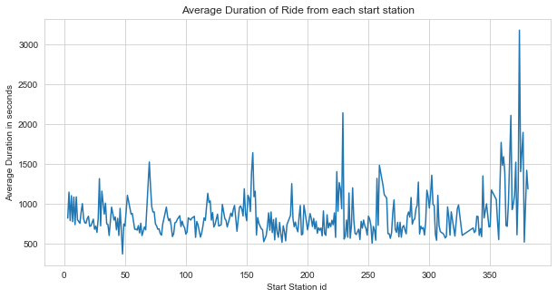

```python
plt.figure(figsize=(10,5))
plt.errorbar(x=mean_start_time['start_station_id'],y=mean_start_time['duration_sec']);
plt.title('Average Duration of Ride from each start station');
plt.xlabel('Start Station id ');
plt.ylabel('Average Duration in seconds');
```

The above graph indicates what is the average duration of ride from each start station . We see that station above 350 seem to have a higher ride time average . That means station above 350 are either located far from downtown or most points of interest . This would be a good area to focus as station having ride duration can give bigger revenue

The company must make sure that enough bikes are always avaliable at this station and if possible people from this station take round trip by which we can also increase ride times more

```python
mean_end_time=bike_share_2018.groupby('end_station_id',as_index=False).mean()
```

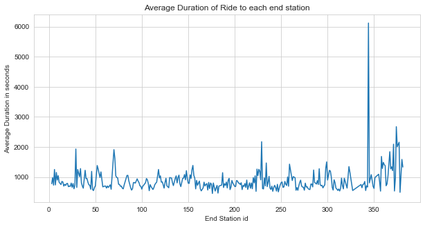

```python
plt.figure(figsize=(10,5))
plt.errorbar(x=mean_end_time['end_station_id'],y=mean_end_time['duration_sec']);
plt.title('Average Duration of Ride to each end station');
plt.xlabel('End Station id ');
plt.ylabel('Average Duration in seconds');
```

The above graph indicates what is the average duration of ride to each end station . We see that station above 350 seem to have a higher ride time average . There is also one location which has a substantial higher average than other . Upon futher investigation of the higher outlier point I feel that rides ending to that station are indeed of higher time . We there must make sure customers travelling to station id 344 get preferance in bike selection over shorter rides to increase revnue if bike numbers are limited by giving ride reservation capability to customers travelling towards those higher end time destinations

```python
# Finding the station id of the outlier
mean_end_time[mean_end_time['duration_sec']==6119.306122448979]
```

|  | end_station_id | bike_id | duration_sec | member_birth_year | start_station_id | end_year | start_year | start_month | end_month |
| --- | --- | --- | --- | --- | --- | --- | --- | --- | --- |
| 301 | 344.0 | 3108.755102 | 6119.306122 | 1980.030612 | 100.061224 | 2018.0 | 2018.0 | 5.969388 | 5.969388 |

```python
bike_share_2018[bike_share_2018['end_station_id']==344]['duration_sec']
```

```
850997      1713
851514       470
853604      1127
856231       632
857342      1259
861064       437
862047       235
862049       238
862698       818
863876       551
863883       443
867081      2763
867958     75915
868761      1066
869813       604
```

[output cut: 47 more lines]

The reason for this station id having so bigger value seems because most rides ending at this station are above the median that is 50-75 percentile range with many outlier points also ending at this station .

This station could be a college or some concert hall type location. Its important that when ever there is a event at this location we should encourage people to use our service

```python
ride_duration_by_month=bike_share_2018.groupby('start_month',as_index=False).mean()
```

```python
ride_duration_by_month.head()
```

|  | start_month | bike_id | duration_sec | end_station_id | member_birth_year | start_station_id | end_year | start_year | end_month |
| --- | --- | --- | --- | --- | --- | --- | --- | --- | --- |
| 0 | 1 | 2047.803847 | 728.455696 | 101.150213 | 1981.056123 | 104.000415 | 2018.0 | 2018.0 | 1.000046 |
| 1 | 2 | 2018.988595 | 750.172420 | 110.022505 | 1981.668129 | 112.228590 | 2018.0 | 2018.0 | 2.000010 |
| 2 | 3 | 2007.255095 | 738.593281 | 113.619579 | 1982.012327 | 115.898848 | 2018.0 | 2018.0 | 3.000059 |
| 3 | 4 | 2112.978544 | 767.484167 | 114.452180 | 1982.170506 | 116.489732 | 2018.0 | 2018.0 | 4.000082 |
| 4 | 5 | 2415.800498 | 768.690942 | 112.215385 | 1982.250934 | 113.697718 | 2018.0 | 2018.0 | 5.000066 |

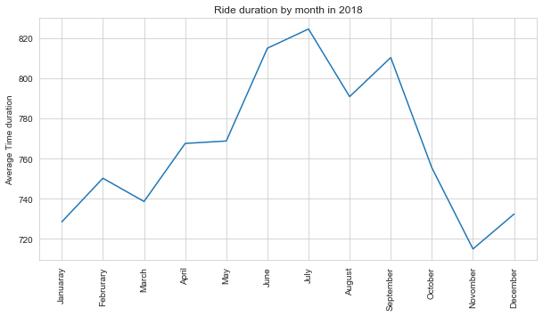

```python
plt.figure(figsize=(10,5))
plt.errorbar(x=ride_duration_by_month['start_month'],y=ride_duration_by_month['duration_sec']);
plt.title('Ride duration by month in 2018');
#plt.xlabel('Month');
plt.ylabel('Average Time duration');
loc=[1,2,3,4,5,6,7,8,9,10,11,12]
labels=['Januaray','Februrary','March','April','May',"June",'July','August','September','October','Novomber','December']
plt.xticks(loc,labels,rotation=90);
```

We see that the rides average duration through spring reaching a max in summer in July and decreasing as winter months approach

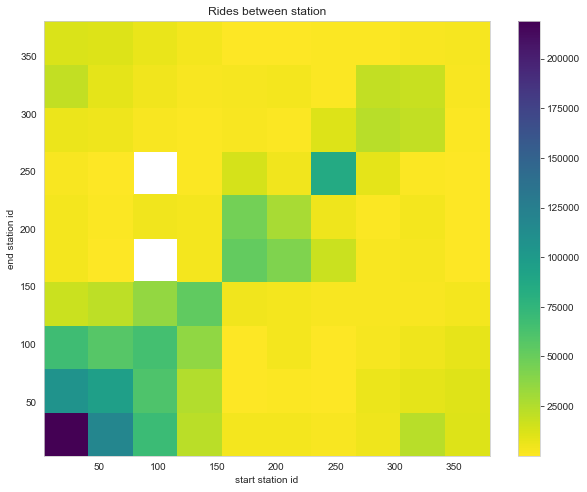

```python
plt.figure(figsize=(10,8));
plt.hist2d(x=bike_share_2018['start_station_id'],y=bike_share_2018['end_station_id'],cmin=0.5,cmap='viridis_r');
plt.colorbar();
plt.xlabel('start station id');
plt.ylabel('end station id');
plt.title("Rides between station");
```

we see that most rides occour between ids of (0-120 ). Commute between this station ids generates a major revenue for the company and hence this routes should be taken care of .

Lets take a more closer look at rides between 0 and 120

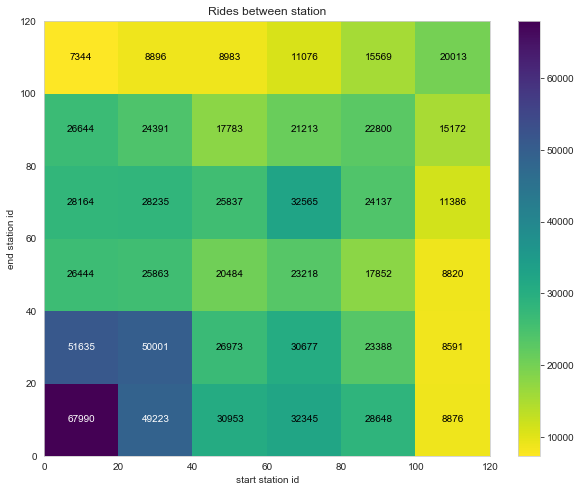

```python
bins_x = np.arange(0, 120+1, 20)
bins_y = np.arange(0, 120+1, 20)
plt.figure(figsize=(10,8));
h2d=plt.hist2d(x=bike_share_2018['start_station_id'],y=bike_share_2018['end_station_id'],cmin=0.5,cmap='viridis_r',bins=[bins_x,bins_y]);
plt.colorbar();
plt.xlim((0,120));
plt.ylim((0,120));
plt.xlabel('start station id');
plt.ylabel('end station id');
plt.title("Rides between station")

counts=h2d[0]
for i in range(counts.shape[0]):
    for j in range(counts.shape[1]):
        c = counts[i,j]
        if c >= 40000: # increase visibility on darkest cells
            plt.text(bins_x[i]+10, bins_y[j]+10, int(c),
                     ha = 'center', va = 'center', color = 'white')
        elif c > 0:
            plt.text(bins_x[i]+10, bins_y[j]+10, int(c),
                     ha = 'center', va = 'center', color = 'black')
```

Even among the zoomed data we see higher number of ridea are taken between station ids 0-40.

By using station ids we can also know whether major revenue comes from shorter rides or longer rides and price accordingly

# Let check if people coming back to the same station id ride longer than people going to the different station id

```python
# Computing mean for same station end and different station end
bike_share[bike_share['end_station_id']==bike_share['start_station_id']]['duration_sec'].mean(),bike_share[bike_share['end_station_id']!=bike_share['start_station_id']]['duration_sec'].mean()
```

```
(1991.4234151034152, 756.0088522172546)
```

We see that the people doing round trip seem to have a higher ride duration . Hence the company should incentivize round trips

# Checking to see if subscriber or customer rides more

```python
bike_share_2018[bike_share_2018['user_type']=='Subscriber']['duration_sec'].mean(),bike_share_2018[bike_share_2018['user_type']=='Customer']['duration_sec'].mean()
```

```
(665.8639476219985, 1601.1466554125343)
```

We see that customer rides more . Thus people who like to ride more are already our customer of our service

```python
bike_usage=bike_share_2018.groupby('bike_id',as_index=False).mean()
```

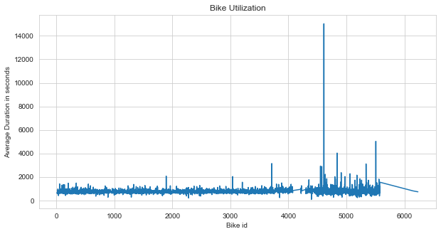

```python
plt.figure(figsize=(10,5))
plt.errorbar(x=bike_usage['bike_id'],y=bike_usage['duration_sec']);
plt.title('Bike Utilization');
plt.xlabel('Bike id ');
plt.ylabel('Average Duration in seconds');
```

This graph can give an idea whether if any particular supplier/comapnies bikes is being preffered by customer/rides  
Seeing the graph we see that most bikes have almost similar usage ( fuluctating between 500-1500 sec range) with few outliers Thus we can conclude that either company had identical bikes and there is no baise in selecting a bike for a trip

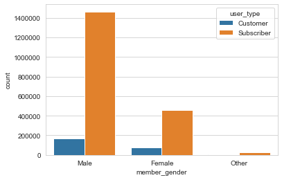

```python
sns.countplot(data=bike_share,x='member_gender',hue='user_type')
```

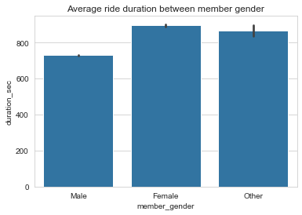

```python
sns.barplot(data=bike_share_2018,x='member_gender',y='duration_sec',color=base_color);
plt.title("Average ride duration between member gender");
```

We see that female customes ride more than male hence we should try to attrack more female users by trageting marketing campaingn towards them

### Interesting relationships between the other features (not the main feature(s) of interest)

- most rides start and end between station id 3-120 with maximum between 0-40 station ids

## Multivariate Exploration

Lets group tine into 4 zones Night(0-6) , Morning (6-12),afternoon(12-6) and evening(6-12)

```python
bike_share_2018['start_hour']=(pd.to_datetime(bike_share_2018['start_time_dt'],format= '%H:%M:%S' ).dt.hour)
```

```python
# Slotting time into various zones of the day as described above
bin_edges = [0,6,12,18,24]
bin_labels=['Night','Morning','Afternoon','Evening']
```

```python
bike_share_2018['day_zone']=pd.cut(bike_share_2018['start_hour'],bin_edges,labels=bin_labels)
```

```python
bike_share_2018.sample(5)
```

|  | bike_id | bike_share_for_all_trip | duration_sec | end_station_id | end_station_name | member_birth_year | member_gender | start_station_id | start_station_name | user_type | start_date_dt | start_time_dt | end_date_dt | end_time_dt | end_year | start_year | start_month | end_month | start_hour | day_zone |
| --- | --- | --- | --- | --- | --- | --- | --- | --- | --- | --- | --- | --- | --- | --- | --- | --- | --- | --- | --- | --- |
| 575117 | 1119 | No | 361 | 74.0 | Laguna St at Hayes St | 1984.0 | Male | 53.0 | Grove St at Divisadero | Subscriber | 2018-01-16 | 09:59:06 | 2018-01-16 | 10:05:07 | 2018 | 2018 | 1 | 1 | 9 | Morning |
| 1103563 | 2601 | No | 212 | 179.0 | Telegraph Ave at 27th St | 1993.0 | Male | 182.0 | 19th Street BART Station | Subscriber | 2018-05-07 | 21:10:06 | 2018-05-07 | 21:13:39 | 2018 | 2018 | 5 | 5 | 21 | Evening |
| 1343935 | 2801 | No | 548 | 350.0 | 8th St at Brannan St | 1985.0 | Female | 124.0 | 19th St at Florida St | Subscriber | 2018-07-31 | 09:24:31 | 2018-07-31 | 09:33:40 | 2018 | 2018 | 7 | 7 | 9 | Morning |
| 2247928 | 1919 | No | 575 | 5.0 | Powell St BART Station (Market St at 5th St) | 1979.0 | Male | 64.0 | 5th St at Brannan St | Subscriber | 2018-11-01 | 15:57:58 | 2018-11-01 | 16:07:33 | 2018 | 2018 | 11 | 11 | 15 | Afternoon |
| 2115460 | 4336 | No | 467 | 80.0 | Townsend St at 5th St | 1993.0 | Female | 23.0 | The Embarcadero at Steuart St | Subscriber | 2018-10-01 | 09:51:04 | 2018-10-01 | 09:58:52 | 2018 | 2018 | 10 | 10 | 9 | Morning |

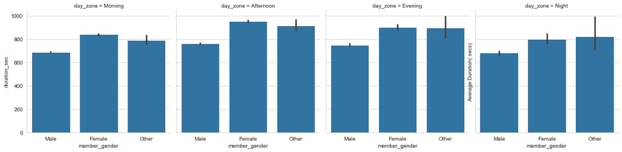

```python
g = sns.FacetGrid(data = bike_share_2018, col = 'day_zone', size = 4,col_order=['Morning','Afternoon','Evening','Night']);
g.map(sns.barplot, 'member_gender', 'duration_sec');
plt.ylabel('Average Duration( secs)')
```

We see that women ride higher in all the four day zones with maximum difference in ride times in afternoon and least in the night

Morning ( 6-12) , Afternon(12-18), Evening(18-0) ,Night(0-6), Bracker numbers are time in 24hrs format

Understanding why women ride are longer duration on average can help us push male ride duration up as well

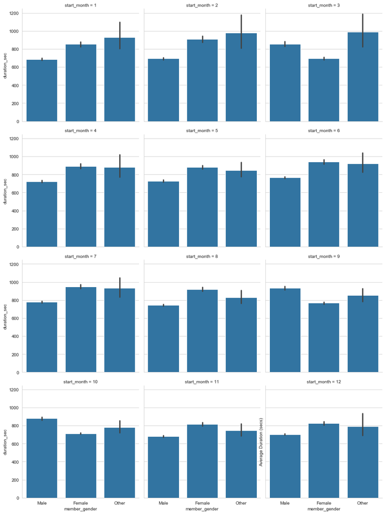

```python
g = sns.FacetGrid(data = bike_share_2018, col = 'start_month', size = 4,col_wrap=3);
g.map(sns.barplot, 'member_gender', 'duration_sec');
#plt.ylabel('Average Duration (secs)');
```

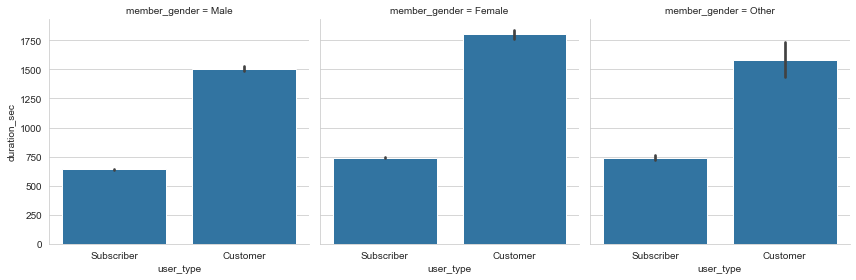

```python
g = sns.FacetGrid(data = bike_share_2018, col = 'member_gender', size = 4);
g.map(sns.barplot, 'user_type', 'duration_sec');
```

We see that customer is driving on average higher than subsciber in all sexes

also the ratio is close to double between customer and subscriber

```python
# Let see how age group affect average time rides
bike_share_2018['age']=2018-bike_share_2018['member_birth_year']
```

```python
bin_edges = [0,15,30,45,60,75,90]
bin_labels=['School','College','Office','Mid-professional','retired','old']
```

```python
bike_share_2018['age_zone']=pd.cut(bike_share_2018['age'],bin_edges,labels=bin_labels)
```

```python
# Checking if the bins are correctly assigned
bike_share_2018.sample(5)
```

|  | bike_id | bike_share_for_all_trip | duration_sec | end_station_id | end_station_name | member_birth_year | member_gender | start_station_id | start_station_name | user_type | ... | end_date_dt | end_time_dt | end_year | start_year | start_month | end_month | start_hour | day_zone | age | age_zone |
| --- | --- | --- | --- | --- | --- | --- | --- | --- | --- | --- | --- | --- | --- | --- | --- | --- | --- | --- | --- | --- | --- |
| 1402092 | 3729 | No | 1561 | 121.0 | Mission Playground | 1992.0 | Male | 66.0 | 3rd St at Townsend St | Customer | ... | 2018-07-22 | 14:50:04 | 2018 | 2018 | 7 | 7 | 14 | Afternoon | 26.0 | College |
| 1359608 | 958 | Yes | 176 | 247.0 | Fulton St at Bancroft Way | 1995.0 | Male | 240.0 | Haste St at Telegraph Ave | Subscriber | ... | 2018-07-28 | 13:50:23 | 2018 | 2018 | 7 | 7 | 13 | Afternoon | 23.0 | College |
| 2239597 | 1474 | No | 962 | 194.0 | Lakeshore Ave at Trestle Glen Rd | 1984.0 | Male | 159.0 | 24th St at Market St | Subscriber | ... | 2018-11-02 | 17:42:04 | 2018 | 2018 | 11 | 11 | 17 | Afternoon | 34.0 | Office |
| 2374330 | 322 | No | 464 | 22.0 | Howard St at Beale St | 1961.0 | Male | 6.0 | The Embarcadero at Sansome St | Subscriber | ... | 2018-12-03 | 17:18:05 | 2018 | 2018 | 12 | 12 | 17 | Afternoon | 57.0 | Mid-professional |
| 2021497 | 1957 | No | 607 | 30.0 | San Francisco Caltrain (Townsend St at 4th St) | 1991.0 | Male | 28.0 | The Embarcadero at Bryant St | Subscriber | ... | 2018-10-15 | 18:25:46 | 2018 | 2018 | 10 | 10 | 18 | Afternoon | 27.0 | College |

5 rows × 22 columns

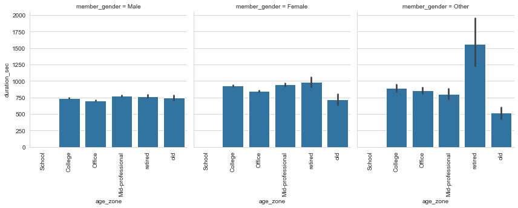

```python
g = sns.FacetGrid(data = bike_share_2018, col = 'member_gender', size = 4);
g.map(sns.barplot, 'age_zone', 'duration_sec');
[plt.setp(ax.get_xticklabels(), rotation=90) for ax in g.axes.flat];
#plt.ylabel('Average Duration ( secs)');
```

We see that among men almost all age zones have close average ride times

Retired females have the highest average ride times followed by mid professional females

Looks like there is no data in 0-15 age bucket as we have seen above the max year in the dataset is 2000 so min age in the data set is 18 years old

The age group buckets are set up as follows  
0-15 yrs School  
15-30 yrs College  
30-45 yrs Office  
45-60 yrs Mid-professional  
60-75 yrs Retired  
75-90 yrs old